# Clinical statistics for non-statisticians: Day three

Steve Simon

## Outline of the three day course

- Day one: Numerical summaries and data visualization
- Day two: Hypothesis testing and sampling
- Day three: Statistical tests to compare treatment to a control and regression models

My goal: help you to become a better consumer of statistics

## Day three topics

- Statistical tests to compare a treatment to a control
  - What tests should you use for categorical outcomes?
  - What tests should you use for continuous outcomes?
  - When should you use nonparametric tests?

## Day three topics (continued)

- Regression models
  - How does a regression model quantify trends
  - How does logistic regression differ from linear regression
  - What is a confounding variable
  - How should you control for or adjust for confounding

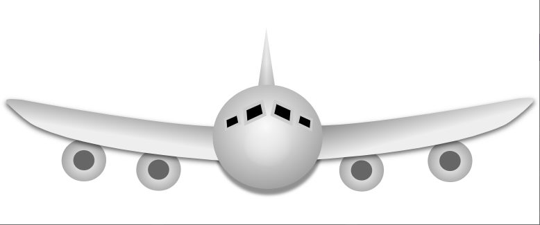

Figure 1: Image of a passenger jet with four engines

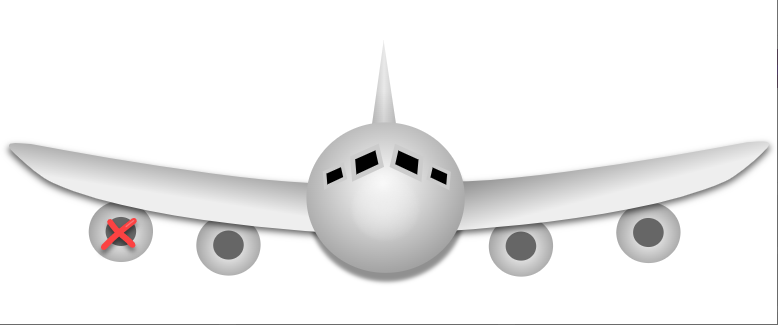

Figure 2: Image of a passenger jet with one bad engine

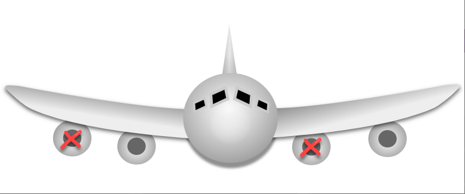

Figure 3: Image of a passenger jet with two bad engines

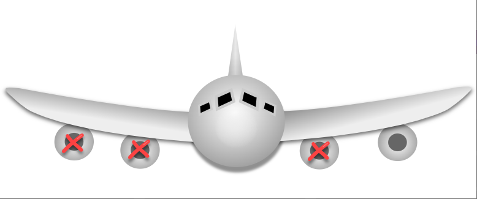

Figure 4: Image of a passenger jet with three bad engines

## Comparison of treatment and control

- Treatment, something new to help a patient
  - Active intervention
  - Randomized trial
- Exposure, something that a patient endures
  - Passive observation
  - Epidemiology study
- Control
  - Placebo, or
  - Usual standard of care

## Comparison of a binary outcome

$$X^2 = \Sigma \frac{(O_{ij}-E_{ij})^2}{E_{ij}}$$

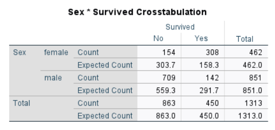

Figure 5: Counts of dead and survived by sex with expected coutns

## Alternative approach, the odds ratio

```
        Died  Survived
Females  154       308
Males    709       142

Survival odds for Females 2 to 1 in favor (308 / 154).
Survival odds for Males 5 to 1 against (142/ 709).

Odds ratio = (2/1) / (1/5) = 10

95% CI (7.7, 13)
```

## Alternative approach, relative risk

```
        Died  Survived
Females  154       308
Males    709       142

Survival probability for 66.7%.
Survival probability for Males 16.7%.

Relative risk = 0.667 / 0.167 = 4

95% CI (3.4, 4.7)
```

## Which is the better measure?

- Two schools of thought
  - Relative risk is better
    - More natural interpretation
  - Odds ratio is better - Symmetric with respect to outcome
- Cannot use relative risk for certain datasets

## Both are inferior to absolute risk reduction

```
        Died  Survived
Females  154       308
Males    709       142

Survival probability for 66.7%.
Survival probability for Males 16.7%.

Absolute risk reduction = 0.667 - 0.167 = 0.5

95% CI (0.45, 0.55)
```

## Comparison of multinomial outcome

- Multinomial = 3 or more categories
- Beyond the scope of this class
  - Multinomial logistic regression
  - Ordinal logistic regression

## Comparison of a continuous outcome

- Two cases
  - Independent (unpaired) samples
  - Paired samples

## Two sample test

- Is $(\bar{X_1}-\bar{X_2})$ close to zero?
- How much sampling error?
  - $S_p\sqrt{\frac{1}{n_1} + \frac{1}{n_2}}$

## Comparison of ages of deaths/survivors

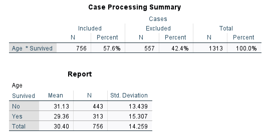

95% CI (-0.3, 3.8)

## Paired samples

```
Room Before  After
 121   11.8   10.1
 125    7.1    3.8
 163    8.2    7.2
 218   10.1   10.5
 233   10.8    8.3
 264   14     12
 324   14.6   12.1
 325   14     13.7
```

## Average change

```
Room Before  After Change
 121   11.8   10.1   -1.7
 125    7.1    3.8   -3.3
 163    8.2    7.2   -1.0
 218   10.1   10.5    0.4
 233   10.8    8.3   -2.5
 264   14     12     -2.0
 324   14.6   12.1   -2.5
 325   14     13.7   -0.3
```

$\bar{D}=-1.61,\ S_D=1.24$

95% CI (-2.65, -0.58)

## Assumptions for t-tests

- t-tests require two or more assumptions
  - Patients are independent
  - Outcome is normally distributed
  - For two sample t-test, equal variation

## Nonparametric test

- Uses ranks of the data
- Does not rely on normality assumption
- Does not rely on Central Limit Theorem

## Wilcoxon signed rank test

```
                           Absolute
Room Before  After Change    Change   Rank
 121   11.8   10.1   -1.7       1.7      4
 125    7.1    3.8   -3.3       3.3      8
 163    8.2    7.2   -1.0       1.0      3
 218   10.1   10.5    0.4       0.4      2
 233   10.8    8.3   -2.5       2.5      6/7
 264   14     12     -2.0       2.0      5
 324   14.6   12.1   -2.5       2.5      6/7
 325   14     13.7   -0.3       0.3      1
```

p = 0.023

## Criticisms of nonparametric tests

- Not easy to get confidence intervals
- Difficult to do risk adjustments

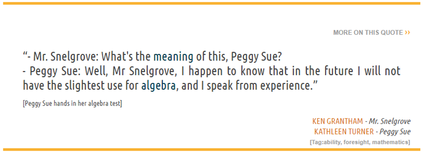

Figure 6: Quote from “Peggy Sue Got Married

## Pop quiz

- From high school algebra.
  - Pythagorean theorem
    - ?
  - Quadratic formula
    - ?
  - Equation for a straight line
    - ?

## Pop quiz answers

- From high school algebra.
  - Pythagorean theorem
    - $a^2+b^2=c^2$
  - Quadratic formula
    - $\frac{-b \pm \sqrt{b^2-4ac}}{2a}$
  - Formula for a straight line
    - $y=mx+b$

## Equation of a straight line

- $y=mx+b$
  - $m=\triangle y / \triangle x$
  - $b=$y-intercept

## Linear regression

## Logistic regression

## Confounding

## Risk adjustment